# Unsupervised Methods

Fabienne Lind & Petro Tolochko

# Preparation

### Required Packages

We first need to install the packages required for further analysis.

```r
# install.packages("tm")
# install.packages("tidyverse")
# install.packages("ggthemes")
# install.packages("ggrepel")
# install.packages("cowplot")
# install.packages("quanteda")
# install.packages("quanteda.textmodels")
# install.packages("gtools")
# install.packages("sotu")
# install.packages("stm")
```

Note: you only need to install the packages once.

We then need load the packages in our environment:

```r
library(tm)
library(tidyverse)
library(ggthemes)
library(ggrepel)
library(quanteda)
library(quanteda.textmodels)
library(gtools)
library(sotu)
library(stm)
```

# K-Means Clustering

## Let’s first generate some data!

We will use multinomial models to generate data. Generate texts about bannas and chocolate.

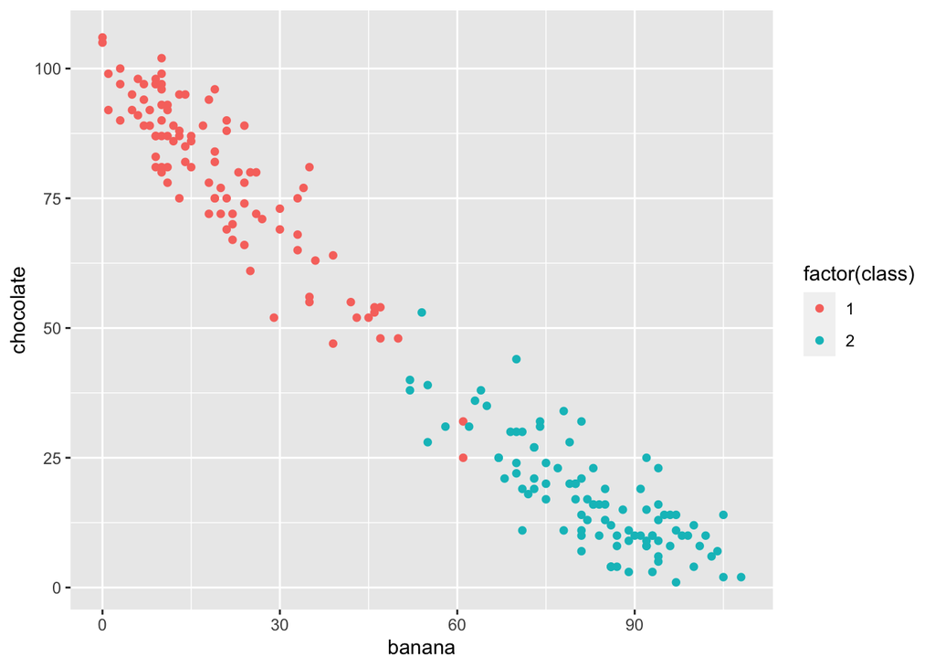

```r
set.seed(123)

# Priors
theta_1 <- rdirichlet(1, c(1, 6))
theta_2 <- rdirichlet(1, c(6, 1))

vocabulary <- c("banana", "chocolate")

w <- 200 # numbers of words to generate
n <- 100

generate_text <- function(n, theta) {
  sample(vocabulary, rbinom(1, n, .5), replace = TRUE, prob = theta) %>%
  paste(collapse = " ")
}



text_type_1 <- replicate(n, generate_text(w, rdirichlet(1, c(2, 8))))
text_type_2 <- replicate(n, generate_text(w, rdirichlet(1, c(8, 2))))




all_texts <- c(text_type_1, text_type_2)
dtm <- DocumentTermMatrix(all_texts) %>% as.matrix()

dtm %>% as_tibble() %>%
  mutate(class = c(rep(1, n), rep(2, n))) %>%
  ggplot() +
  geom_point(aes(banana, chocolate, color = factor(class)))
```

```r
#
#
#
# # Modesl
# texts_1 <- rmultinom(n, 2, theta_1) %>%
#   t() %>%
#   as_tibble() %>%
#   mutate(banan = V1,
#          chocolate = V2,
#          type = 1) %>%
#   select(-V1, -V2)
#
# texts_2 <- rmultinom(n, 2, theta_2) %>%
#   t() %>%
#   as_tibble() %>%
#     mutate(banan = V1,
#          chocolate = V2,
#          type = 2) %>%
#   select(-V1, -V2)
```

# Now let’s try clustering them!

It’s very easy. We’re using `kmeans` function from base `r`.

```r
clustering.kmeans <- kmeans(dtm, 2)
clustering.kmeans
```

```
## K-means clustering with 2 clusters of sizes 98, 102
##
## Cluster means:
##     banana chocolate
## 1 18.93878  80.51020
## 2 82.25490  17.59804
##
## Clustering vector:
##   1   2   3   4   5   6   7   8   9  10  11  12  13  14  15  16  17  18  19  20
##   1   1   1   1   1   1   1   1   1   1   1   1   1   1   1   1   1   1   1   1
##  21  22  23  24  25  26  27  28  29  30  31  32  33  34  35  36  37  38  39  40
##   1   1   1   1   1   1   1   1   1   1   1   1   2   1   1   1   1   1   1   1
##  41  42  43  44  45  46  47  48  49  50  51  52  53  54  55  56  57  58  59  60
##   1   1   1   1   1   1   1   1   1   1   1   1   1   1   2   1   1   1   1   1
##  61  62  63  64  65  66  67  68  69  70  71  72  73  74  75  76  77  78  79  80
##   1   1   1   1   1   1   1   1   1   1   1   1   1   1   1   1   1   1   1   1
##  81  82  83  84  85  86  87  88  89  90  91  92  93  94  95  96  97  98  99 100
##   1   1   2   1   1   1   1   1   1   1   1   1   1   1   1   1   1   1   1   1
## 101 102 103 104 105 106 107 108 109 110 111 112 113 114 115 116 117 118 119 120
##   2   2   2   2   2   2   2   2   2   2   2   2   2   1   2   2   2   2   2   2
## 121 122 123 124 125 126 127 128 129 130 131 132 133 134 135 136 137 138 139 140
##   2   2   2   2   2   2   2   2   2   2   2   2   2   2   2   2   2   2   2   2
## 141 142 143 144 145 146 147 148 149 150 151 152 153 154 155 156 157 158 159 160
##   2   2   2   2   2   2   2   2   2   2   2   2   2   2   2   2   2   2   2   2
## 161 162 163 164 165 166 167 168 169 170 171 172 173 174 175 176 177 178 179 180
##   2   2   2   2   2   2   2   2   2   2   2   2   2   2   2   2   2   2   2   2
## 181 182 183 184 185 186 187 188 189 190 191 192 193 194 195 196 197 198 199 200
##   2   2   2   2   2   2   2   2   2   2   2   2   2   2   2   2   2   2   2   2
##
## Within cluster sum of squares by cluster:
## [1] 35612.12 29089.89
##  (between_SS / total_SS =  86.0 %)
##
## Available components:
##
## [1] "cluster"      "centers"      "totss"        "withinss"     "tot.withinss"
## [6] "betweenss"    "size"         "iter"         "ifault"
```

Let’s look at the cluster assignment:

```r
cluster <- clustering.kmeans$cluster
centroids <- clustering.kmeans$centers
```

And assign to our data:

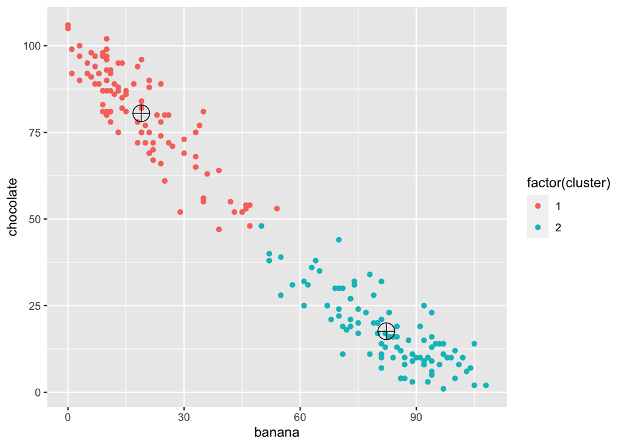

```r
dtm %>% as_tibble() %>%
  mutate(cluster = cluster) %>%
  ggplot() +
  geom_point(aes(banana, chocolate, color = factor(cluster))) +
  geom_point(aes(banana, chocolate), data = as_tibble(centroids),
             size = 6, shape = 10)
```

Ok, let’s add some more data!

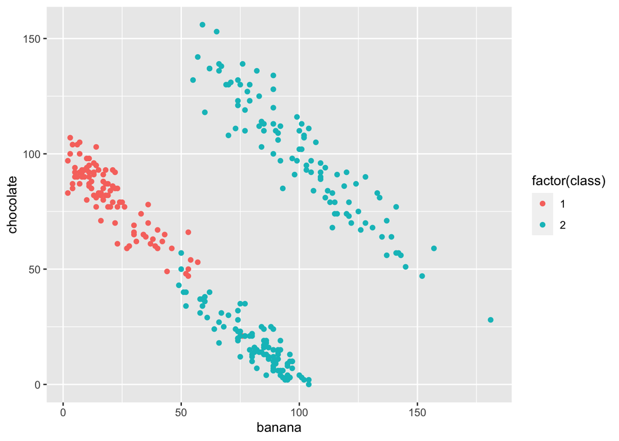

```r
text_type_1 <- replicate(n, generate_text(w, rdirichlet(1, c(2, 8))))
text_type_2 <- replicate(n, generate_text(w, rdirichlet(1, c(8, 2))))
text_type_3 <- replicate(n, generate_text(w + 200, rdirichlet(1, c(8, 8))))




all_texts <- c(text_type_1, text_type_2, text_type_3)
dtm <- DocumentTermMatrix(all_texts) %>% as.matrix()

dtm %>% as_tibble() %>%
  mutate(class = c(rep(1, n), rep(2, n), rep(2, n))) %>%
  ggplot() +
  geom_point(aes(banana, chocolate, color = factor(class)))
```

A bit more interesting!

```r
clustering.kmeans <- kmeans(dtm, 3)
clustering.kmeans
```

```
## K-means clustering with 3 clusters of sizes 97, 104, 99
##
## Cluster means:
##      banana chocolate
## 1  19.68041  81.58763
## 2  81.70192  18.53846
## 3 100.41414 100.28283
##
## Clustering vector:
##   1   2   3   4   5   6   7   8   9  10  11  12  13  14  15  16  17  18  19  20
##   1   1   1   1   1   1   1   1   1   1   1   1   2   2   1   1   1   1   1   1
##  21  22  23  24  25  26  27  28  29  30  31  32  33  34  35  36  37  38  39  40
##   1   1   1   1   1   2   1   1   1   1   1   1   1   1   1   1   1   1   1   1
##  41  42  43  44  45  46  47  48  49  50  51  52  53  54  55  56  57  58  59  60
##   1   1   1   1   1   1   1   1   1   1   1   1   1   1   1   2   1   1   1   1
```

[output cut: 33 more lines]

```r
cluster <- clustering.kmeans$cluster
centroids <- clustering.kmeans$centers
```

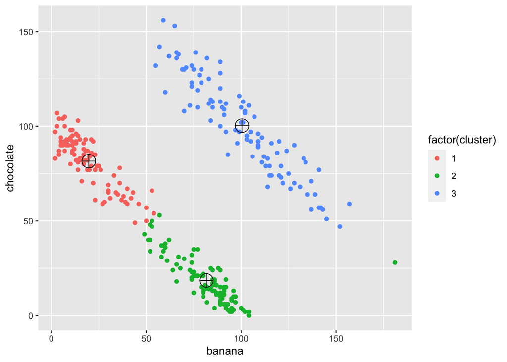

```r
dtm %>% as_tibble() %>%
  mutate(cluster = cluster) %>%
  ggplot() +
  geom_point(aes(banana, chocolate, color = factor(cluster))) +
  geom_point(aes(banana, chocolate), data = as_tibble(centroids),
             size = 6, shape = 10)
```

# Task: try different number of clusters and complare the clustering solution

# Topic Modeling

We will be using the `stm` package and `sotu` data.

First, let’s load up the data:

```r
sotu <- sotu_text %>% as_tibble()
sotu_metadata <- sotu_meta %>% as_tibble()




sotu <- bind_cols(sotu, sotu_metadata)

summary(sotu)
```

```
##     value                 X           president              year
##  Length:240         Min.   :  1.00   Length:240         Min.   :1790
##  Class :character   1st Qu.: 60.75   Class :character   1st Qu.:1849
##  Mode  :character   Median :120.50   Mode  :character   Median :1908
##                     Mean   :120.50                      Mean   :1907
##                     3rd Qu.:180.25                      3rd Qu.:1965
##                     Max.   :240.00                      Max.   :2020
##  years_active          party            sotu_type
##  Length:240         Length:240         Length:240
##  Class :character   Class :character   Class :character
##  Mode  :character   Mode  :character   Mode  :character
##
##
##
```

Ok, we need to do basic preprocessing. We can do that immediately within the infrastructure of the `stm` package, with the `textProcessor` function.

This will take a few seconds…

```r
sotu_data <- textProcessor(
  sotu$value,
  metadata = sotu_meta
)
```

```
## Building corpus...
## Converting to Lower Case...
## Removing punctuation...
## Removing stopwords...
## Removing numbers...
## Stemming...
## Creating Output...
```

Ok, now we have the processed object.

```r
sotu_data
```

```
## A text corpus with 240 documents, and an 18604 word dictionary.
```

Next, we need to prepare the documents for topic modeling. This is done with the `prepDocuments` function

```r
sotu_data_prepd <- prepDocuments(sotu_data$documents,
                                 sotu_data$vocab,
                                 sotu_data$meta)
```

```
## Removing 8544 of 18604 terms (8544 of 302187 tokens) due to frequency
## Your corpus now has 240 documents, 10060 terms and 293643 tokens.
```

Now we’re ready for some modelling! This will also take some time.

[output not shown]

[output cut: 145 more lines]

[output not shown]

When the model is done running, we can inspect the output. Different possible ways to do so:

```r
labelTopics(sotu_topic_10)
```

```
## Topic 1 Top Words:
##       Highest Prob: will, govern, year, nation, congress, feder, can
##       FREX: agricultur, dollar, veteran, expenditur, relief, wage, fiscal
##       Lift: -cent, amort, herbert, multiple-purpos, mustering-, reinsur, well-balanc
##       Score: program, reconvers, budget, lend-leas, peacetim, demobil, wartim
## Topic 2 Top Words:
##       Highest Prob: govern, law, state, nation, will, great, countri
##       FREX: interst, philippin, canal, corpor, forest, supervis, panama
##       Lift: -knot, alley, alsop, amiabl, aright, assuag, battle-ship
##       Score: wage-work, hagu, interst, isthmus, filipino, battleship, anarchist
## Topic 3 Top Words:
##       Highest Prob: will, american, year, america, work, peopl, can
##       FREX: theyr, that, kid, weve, terrorist, dont, thank
##       Lift: ---, -school, -year-old, airmen, al-baghdadi, alic, alltim
##       Score: tonight, that, weve, terrorist, dont, iraq, job
## Topic 4 Top Words:
##       Highest Prob: state, will, govern, unit, may, public, nation
##       FREX: intercours, tribe, disposit, militia, navig, franc, portion
##       Lift: animadvers, atkinson, augustin, conjunctur, dey, florin, hanseat
##       Score: intercours, correspond, commenc, stipul, navig, expedi, vessel
## Topic 5 Top Words:
##       Highest Prob: will, year, new, can, american, govern, nation
##       FREX: vietnam, percent, crime, spend, billion, budget, tonight
##       Lift: alliesw, childreni, commitmentsw, defense-rel, expansionari, freshmen, garbag
##       Score: tonight, program, vietnam, budget, percent, agenda, job
## Topic 6 Top Words:
##       Highest Prob: nation, will, war, must, peopl, world, can
##       FREX: enemi, japanes, victori, german, thought, battl, selfish
##       Lift: autocraci, far-flung, feroci, generalissimo, good-wil, indescrib, overemphas
##       Score: nazi, hitler, fascist, autocraci, programm, cruiser, tank
## Topic 7 Top Words:
##       Highest Prob: state, govern, unit, congress, will, countri, upon
##       FREX: mexico, texa, mexican, territori, slaveri, constitut, california
##       Lift: -estim, affluenc, antislaveri, astoria, aver, behr, bloodless
##       Score: whilst, steamer, commenc, stipul, annex, pared, postmaster-gener
## Topic 8 Top Words:
##       Highest Prob: will, year, program, nation, congress, administr, develop
##       FREX: oil, energi, regulatori, implement, ensur, environment, signific
##       Lift: --pocket, -fault, -ship, -util, adolesc, alternativesprogram, anda
##       Score: program, nuclear, soviet, environment, ensur, technolog, sector
## Topic 9 Top Words:
##       Highest Prob: nation, will, world, must, free, peopl, peac
##       FREX: communist, soviet, freedom, free, atom, aggress, weapon
##       Lift: -produc, alliesand, anti-guerrilla, forcesand, foundation-ston, futureand, hormuz
##       Score: soviet, communist, program, nuclear, atom, basic, today
## Topic 10 Top Words:
##       Highest Prob: govern, state, year, will, unit, upon, congress
##       FREX: silver, gold, bond, pension, cent, per, commission
##       Lift: -inch, allotte, bancroft, bereav, brakemen, cane, cheyenn
##       Score: circul, coinag, post-offic, commission, postmaster-gener, intercours, silver
```